# Preprocessing for ecotoxicological prediction in R

## Introduction

In this session, we will link ecotoxicological data to databases that support predictive modeling and we will illustrate how to calculate chemical similarity.

To work with realistic data, we will use data from the EPA Ecotoxicology database. We use the data from the `standartox` R package, which has undergone some pre-processing and outlier removal.

```
## ECOTOX database file not present! Invoke download and
## database build using 'download_ecotox_data()'
```

```
## biomonitoR 0.9.4
```

```
## R.matlab v3.7.0 (2022-08-25 21:52:34 UTC) successfully loaded. See ?R.matlab for help.
```

```r
# Query database and store locally to avoid querying each time
dat <- stx_data(stx_dir = "/Users/ralfs/R/0_datasets/standartox")
tax <- stx_taxa(stx_dir = "/Users/ralfs/R/0_datasets/standartox")
che <- stx_chem(stx_dir = "/Users/ralfs/R/0_datasets/standartox")
# merge data
dat2 <- merge(dat, tax, by = 'tl_id', all.x = TRUE)
dat3 <- merge(dat2, che, by = 'cl_id', all.x = TRUE)
# save(dat3, file = "Standartox.Rdata")
# to load requires the bit64 package
```

[output not shown]

[output not shown]

[output not shown]

[output not shown]

[output not shown]

[output not shown]

[output not shown]

[output not shown]

[output not shown]

[output not shown]

[output not shown]

[output not shown]

[output not shown]

[output not shown]

[output not shown]

[output not shown]

We limit the dataset to Ephemeropterans, measured toxicity (i.e. ignoring *larger than* values), mortality, median toxic concentrations *XX50* and to test durations between 24 and 120 h. Then we check the taxonomic level of the results as well as the units of the concentrations.

```r
dat4 <- dat3 %>% filter(qualifier == "=" & tax_order == "Ephemeroptera" & effect == "mortality" & endpoint_group == "XX50" & between(duration, 24, 120))

# display concentration units and level
dat4 %>% select(concentration_unit, tax_rank) %>% table()
```

```
##                   tax_rank
## concentration_unit family genus species subspecies
##                g/g      3     0       0          0
##                g/l      8   188     471          1
##                ppb      1    12     292          0
```

A relevant fraction of tests has been done with organisms that were only identified to family or genus level. It remains open whether the tests were done with mixtures of taxa or identification was limited to higher taxonomic levels. The most likely explanation is that the taxa were not identified to species level. How to deal with this situation depends on the purpose of the study. If the aim is, for example, prediction and the data would be considered independent, this could incur bias if in reality the same taxon was tested. Here, we limit the data to the species level.

```r
dat4_spec <- dat4[tax_rank == "species", ]
```

Moreover, we bring all concentrations to the same unit. As an approximation, ppb corresponds to µg L<sup>-1</sup>. We create a small function for conversion and then convert the concentrations where the unit of the concentration is ppb. This can easily be done with the `case_when()` function used within `mutate()`.

```r
# convert ppb to g/l
ppb_to_gL <- function(ppb) {
  ppb * 1e-6
}


dat4_fin <- dat4_spec %>%
  mutate(concentration = case_when(
            concentration_unit == "ppb" ~ ppb_to_gL(concentration),
        TRUE ~ concentration),
        concentration_unit = "g/L")
```

The dataset contains multiple entries per species-chemical combination, which we aggregated with the geometric mean.

```r
dat5 <- dat4_fin %>%
            group_by(tax_family, tax_genus, tax_taxon, casnr.x, cas, common_name, concentration_unit) %>%
            summarise(geo_mean = exp(mean(log(concentration))), .groups = "drop")
```

We now identify the unique chemicals in the data set for which we extract physicochemical information and compute the similarity.

```r
chemicals <- dat5 %>%
                    select(casnr.x, cas, common_name) %>%
                    distinct()
# count chemicals
nrow(chemicals)
```

```
## [1] 232
```

We have 232 different chemicals. We will only focus on a subset, because most queries will connect to servers and this would otherwise take a bit longer. First, we use the function `websearch_comptox()` of the `ECOTOXr` package to connect to the [COMPTOX dashboard](https://comptox.epa.gov/dashboard) of the US EPA, which provides a wide range of information on chemicals and their toxicity.

```r
# subset to first 10 chemicals
chem_sub <- chemicals[1:10, ]

# query comptox
comptox_results <- websearch_comptox(chem_sub$cas)

# look at results
comptox_results
```

```
## $`Cover Sheet`
## # A tibble: 5 × 2
##   `Search property` Result
##   <chr>             <chr>
## 1 Search datestamp  2026-04-25 15:13:51
## 2 Search term count 10.0
## 3 Found count       10.0
## 4 Not found count   0.0
## 5 Duplicate count   0.0
##
## $`Main Data`
## # A tibble: 10 × 63
##    INPUT  FOUND_BY DTXSID PREFERRED_NAME DTXCID CASRN INCHIKEY IUPAC_NAME SMILES
##    <chr>  <chr>    <chr>  <chr>          <chr>  <chr> <chr>    <chr>      <chr>
##  1 38641… CASRN    DTXSI… Glyphosate is… DTXCI… 3864… ZEKANFG… N-(Phosph… "CC(C…
##  2 60-51… CASRN    DTXSI… Dimethoate     DTXCI… 60-5… MCWXGJI… O,O-Dimet… "CNC(…
##  3 108-9… CASRN    DTXSI… Phenol         DTXCI… 108-… ISWSIDI… Phenol     "OC1=…
##  4 7440-… CASRN    DTXSI… Cadmium        DTXCI… 7440… BDOSMKK… Cadmium    "[Cd]"
##  5 7664-… CASRN    DTXSI… Ammonia gas    DTXCI… 7664… QGZKDVF… Ammonia    "N"
##  6 10124… CASRN    DTXSI… Cadmium sulfa… DTXCI… 1012… QCUOBSQ… Cadmium s… "[Cd+…
##  7 12125… CASRN    DTXSI… Ammonium chlo… DTXCI… 1212… NLXLAEX… Ammonium … "[NH4…
##  8 52315… CASRN    DTXSI… Cypermethrin   DTXCI… 5231… KAATUXN… Cyano(3-p… "CC1(…
##  9 60207… CASRN    DTXSI… Propiconazole  DTXCI… 6020… STJLVHW… 1-{[2-(2,… "CCCC…
## 10 11198… CASRN    DTXSI… Thiacloprid    DTXCI… 1119… HOKKPVI… {(2Z)-3-[… "ClC1…
## # ℹ 54 more variables: INCHI_STRING <chr>, MS_READY_SMILES <chr>,
## #   QSAR_READY_SMILES <chr>, MOLECULAR_FORMULA <chr>, AVERAGE_MASS <dbl>,
## #   MONOISOTOPIC_MASS <dbl>, QC_LEVEL <dbl>, SAFETY_DATA <lgl>, EXPOCAST <chr>,
## #   DATA_SOURCES <dbl>, TOXVAL_DATA <chr>, NUMBER_OF_PUBMED_ARTICLES <chr>,
## #   PUBCHEM_DATA_SOURCES <chr>, CPDAT_COUNT <chr>, IRIS_LINK <chr>,
## #   PPRTV_LINK <chr>, WIKIPEDIA_ARTICLE <chr>, QC_NOTES <chr>,
## #   TOXPRINT_FINGERPRINT <chr>, ACTOR_REPORT <chr>, …
##
## $`Abstract Sifter`
## # A tibble: 10 × 3
##    DSSTOX_LINK_TO_DASHBOARD PREFERRED_NAME            `CHEMICAL/ENTITY_QUERY`
##    <chr>                    <chr>                     <chr>
##  1 DTXSID0034649            Glyphosate isopropylamine 38641-94-0 OR Glyphosate …
##  2 DTXSID7020479            Dimethoate                60-51-5 OR Dimethoate
##  3 DTXSID5021124            Phenol                    108-95-2 OR Phenol
##  4 DTXSID1023940            Cadmium                   7440-43-9 OR Cadmium
```

[output cut: 83 more lines]

```
## $`Chemical Properties`
## # A tibble: 192 × 8
##    DTXSID        DTXCID        TYPE         NAME  VALUE UNITS SOURCE DESCRIPTION
##    <chr>         <chr>         <chr>        <chr> <chr> <chr> <chr>  <chr>
##  1 DTXSID0034649 DTXCID8014649 experimental Estr… 0.0   Bina… OPERA… "OPERA v2.…
##  2 DTXSID7034961 DTXCID5014961 experimental Estr… 0.0   Bina… OPERA… "OPERA v2.…
##  3 DTXSID7034961 DTXCID5014961 experimental Estr… 0.0   Bina… OPERA… "OPERA v2.…
##  4 DTXSID7034961 DTXCID5014961 experimental Estr… 0.0   Bina… OPERA… "OPERA v2.…
##  5 DTXSID7034961 DTXCID5014961 experimental Frac… 0.28… Dime… OPERA… "OPERA v2.…
##  6 DTXSID7034961 DTXCID5014961 experimental In V… 2.57  uL/m… OPERA… "OPERA v2.…
##  7 DTXSID7034961 DTXCID5014961 experimental Wate… 7.24… mol/L OPERA… "OPERA v2.…
##  8 DTXSID7034961 DTXCID5014961 predicted    pKa … 0.75  Log1… OPERA… "<a href=\…
##  9 DTXSID5021124 DTXCID501124  experimental Andr… 0.0   Bina… OPERA… "OPERA v2.…
## 10 DTXSID5021124 DTXCID501124  experimental Andr… 0.0   Bina… OPERA… "OPERA v2.…
## # ℹ 182 more rows
```

We obtain a wide range of data.

```r
comptox_results$`Main Data`
```

| INPUT | FOUND_BY | DTXSID | PREFERRED_NAME | DTXCID | CASRN | INCHIKEY | IUPAC_NAME | SMILES | INCHI_STRING | MS_READY_SMILES | QSAR_READY_SMILES | MOLECULAR_FORMULA | AVERAGE_MASS | MONOISOTOPIC_MASS | QC_LEVEL | SAFETY_DATA | EXPOCAST | DATA_SOURCES | TOXVAL_DATA | NUMBER_OF_PUBMED_ARTICLES | PUBCHEM_DATA_SOURCES | CPDAT_COUNT | IRIS_LINK | PPRTV_LINK | WIKIPEDIA_ARTICLE | QC_NOTES | TOXPRINT_FINGERPRINT | ACTOR_REPORT | BIOCONCENTRATION_FACTOR_TEST_PRED | … |
| --- | --- | --- | --- | --- | --- | --- | --- | --- | --- | --- | --- | --- | --- | --- | --- | --- | --- | --- | --- | --- | --- | --- | --- | --- | --- | --- | --- | --- | --- | --- |
| 38641-94-0 | CASRN | DTXSID0034649 | Glyphosate isopropylamine | DTXCID8014649 | 38641-94-0 | ZEKANFGSDXODPD-UHFFFAOYSA-N | N-(Phosphonomethyl)glycine--propan-2-amine (1/1) | CC(C)N.OC(=O)CNCP(O)(O)=O | InChI=1S/C3H8NO5P.C3H9N/c5-3(6)1-4-2-10(7,8)9;1-3(2)4/h4H,1-2H2,(H,5,6)(H2,7,8,9);3H,4H2,1-2H3\n | OC(=O)CNCP(O)(O)=O,CC(C)N | OC(=O)CNCP(O)(O)=O | C6H17N2O5P | 228.185 | 228.08751 | 1 | NA | Y | 26 | Y | - | - | - | NA | NA | NA | NA | - | https://actorws.epa.gov/actorws/actor/2015q3/chemicalPdfExport.pdf?casrn=38641-94-0 | NA | … |
| 60-51-5 | CASRN | DTXSID7020479 | Dimethoate | DTXCID50479 | 60-51-5 | MCWXGJITAZMZEV-UHFFFAOYSA-N | O,O-Dimethyl S-[2-(methylamino)-2-oxoethyl] phosphorodithioate | CNC(=O)CSP(=S)(OC)OC | InChI=1S/C5H12NO3PS2/c1-6-5(7)4-12-10(11,8-2)9-3/h4H2,1-3H3,(H,6,7)\n | CNC(=O)CSP(=S)(OC)OC | CNC(=O)CSP(=S)(OC)OC | C5H12NO3PS2 | 229.250 | 228.99962 | 1 | NA | Y | 159 | Y | - | - | - | Y | NA | Y | NA | - | https://actorws.epa.gov/actorws/actor/2015q3/chemicalPdfExport.pdf?casrn=60-51-5 | 3.707214 | … |
| 108-95-2 | CASRN | DTXSID5021124 | Phenol | DTXCID501124 | 108-95-2 | ISWSIDIOOBJBQZ-UHFFFAOYSA-N | Phenol | OC1=CC=CC=C1 | InChI=1S/C6H6O/c7-6-4-2-1-3-5-6/h1-5,7H\n | OC1=CC=CC=C1 | OC1=CC=CC=C1 | C6H6O | 94.113 | 94.04186 | 1 | NA | Y | 204 | Y | - | - | - | Y | NA | Y | From the CAMEO dataset: https://cameochemicals.noaa.gov/chemical/5114 | - | https://actorws.epa.gov/actorws/actor/2015q3/chemicalPdfExport.pdf?casrn=108-95-2 | 7.610517 | … |
| 7440-43-9 | CASRN | DTXSID1023940 | Cadmium | DTXCID303940 | 7440-43-9 | BDOSMKKIYDKNTQ-UHFFFAOYSA-N | Cadmium | [Cd] | InChI=1S/Cd\n | NA | NA | Cd | 112.414 | 113.90336 | 1 | NA | NA | 137 | Y | - | - | - | Y | NA | Y | REGULATORY: The regulatory limits for Cadmium as a pollutant in biosolids is defined in 40CFR Section 503.13. | - | https://actorws.epa.gov/actorws/actor/2015q3/chemicalPdfExport.pdf?casrn=7440-43-9 | NA | … |
| 7664-41-7 | CASRN | DTXSID0023872 | Ammonia gas | DTXCID803872 | 7664-41-7 | QGZKDVFQNNGYKY-UHFFFAOYSA-N | Ammonia | N | InChI=1S/H3N/h1H3\n | NA | NA | H3N | 17.031 | 17.02655 | 1 | NA | NA | 127 | Y | - | - | - | Y | Y | Y | NA | - | https://actorws.epa.gov/actorws/actor/2015q3/chemicalPdfExport.pdf?casrn=7664-41-7 | NA | … |
| 10124-36-4 | CASRN | DTXSID1020229 | Cadmium sulfate (1:1) | DTXCID30229 | 10124-36-4 | QCUOBSQYDGUHHT-UHFFFAOYSA-L | Cadmium sulfate | [Cd++].[O-]S([O-])(=O)=O | InChI=1S/Cd.H2O4S/c;1-5(2,3)4/h;(H2,1,2,3,4)/q+2;/p-2\n | NA | NA | CdO4S | 208.470 | 209.85510 | 1 | NA | NA | 50 | Y | - | - | - | NA | NA | Y | [31119-53-6] is an Alternate CAS RN for this chemical; DTXSID801015557;\r\n\r\nRecord was reviewed with Common Chemistry. | - | https://actorws.epa.gov/actorws/actor/2015q3/chemicalPdfExport.pdf?casrn=10124-36-4 | NA | … |
| 12125-02-9 | CASRN | DTXSID0020078 | Ammonium chloride | DTXCID3078 | 12125-02-9 | NLXLAEXVIDQMFP-UHFFFAOYSA-N | Ammonium chloride | [NH4+].[Cl-] | InChI=1S/ClH.H3N/h1H;1H3\n | NA | NA | ClH4N | 53.490 | 53.00323 | 1 | NA | NA | 80 | Y | - | - | - | NA | NA | Y | [1448438-95-6] and [152128-19-3] are Alternate CAS Numbers' for this chemical; DTXSID401015131 and \r\nDTXSID501015134 | - | https://actorws.epa.gov/actorws/actor/2015q3/chemicalPdfExport.pdf?casrn=12125-02-9 | NA | … |
| 52315-07-8 | CASRN | DTXSID1023998 | Cypermethrin | DTXCID003998 | 52315-07-8 | KAATUXNTWXVJKI-UHFFFAOYNA-N | Cyano(3-phenoxyphenyl)methyl 3-(2,2-dichloroethen-1-yl)-2,2-dimethylcyclopropane-1-carboxylate | CC1(C)C(C=C(Cl)Cl)C1C(=O)OC(C#N)C1=CC=CC(OC2=CC=CC=C2)=C1 | InChI=1/C22H19Cl2NO3/c1-22(2)17(12-19(23)24)20(22)21(26)28-18(13-25)14-7-6-10-16(11-14)27-15-8-4-3-5-9-15/h3-12,17-18,20H,1-2H3\n | CC1(C)C(C=C(Cl)Cl)C1C(=O)OC(C#N)C1=CC=CC(OC2=CC=CC=C2)=C1 | CC1(C)C(C=C(Cl)Cl)C1C(=O)OC(C#N)C1=CC=CC(OC2=CC=CC=C2)=C1 | C22H19Cl2NO3 | 416.300 | 415.07420 | 1 | NA | Y | 121 | Y | - | - | - | Y | NA | Y | NA | - | https://actorws.epa.gov/actorws/actor/2015q3/chemicalPdfExport.pdf?casrn=52315-07-8 | 741.219189 | … |
| 60207-90-1 | CASRN | DTXSID8024280 | Propiconazole | DTXCID204280 | 60207-90-1 | STJLVHWMYQXCPB-UHFFFAOYNA-N | 1-{[2-(2,4-Dichlorophenyl)-4-propyl-1,3-dioxolan-2-yl]methyl}-1H-1,2,4-triazole | CCCC1COC(CN2C=NC=N2)(O1)C1=C(Cl)C=C(Cl)C=C1 | InChI=1/C15H17Cl2N3O2/c1-2-3-12-7-21-15(22-12,8-20-10-18-9-19-20)13-5-4-11(16)6-14(13)17/h4-6,9-10,12H,2-3,7-8H2,1H3\n | CCCC1COC(CN2C=NC=N2)(O1)C1=C(Cl)C=C(Cl)C=C1 | CCCC1COC(CN2C=NC=N2)(O1)C1=C(Cl)C=C(Cl)C=C1 | C15H17Cl2N3O2 | 342.220 | 341.06978 | 1 | NA | Y | 134 | Y | - | - | - | Y | NA | Y | NA | - | https://actorws.epa.gov/actorws/actor/2015q3/chemicalPdfExport.pdf?casrn=60207-90-1 | 102.017272 | … |
| 111988-49-9 | CASRN | DTXSID7034961 | Thiacloprid | DTXCID5014961 | 111988-49-9 | HOKKPVIRMVDYPB-UVTDQMKNSA-N | {(2Z)-3-[(6-Chloropyridin-3-yl)methyl]-1,3-thiazolidin-2-ylidene}cyanamide | ClC1=CC=C(CN2CCS\\C2=N/C#N)C=N1 | InChI=1S/C10H9ClN4S/c11-9-2-1-8(5-13-9)6-15-3-4-16-10(15)14-7-12/h1-2,5H,3-4,6H2/b14-10-\n | ClC1=CC=C(CN2CCSC2=NC#N)C=N1 | ClC1=CC=C(CN2CCSC2=NC#N)C=N1 | C10H9ClN4S | 252.720 | 252.02365 | 1 | NA | Y | 102 | Y | - | - | - | NA | NA | Y | NA | - | https://actorws.epa.gov/actorws/actor/2015q3/chemicalPdfExport.pdf?casrn=111988-49-9 | NA | … |

**Inspect the data yourself. Why do some compounds consistently lack information for the octanol water partition coefficient, water solubility, vapor pressure and similar variables?**

The package `ECOTOXr` provides also a function to access the Ecotoxicology database of the US EPA, i.e. the raw data, while these data have been polished in the Standartox database. For further details see the article by [Vries (2024)](https://doi.org/10.1016/j.chemosphere.2024.143078).

We can also query physico-chemical properties from the [PubChem database](https://pubchem.ncbi.nlm.nih.gov). This can be done using the function `pc_prop` in the package `webchem`. For detailed information on webchem see the article by [Szöcs et al. (2020)](https://www.jstatsoft.org/article/view/v093i13). To use this function, we first need the so-called Pubchem Compound ID (CID), which can be queried using the function `get_cid()`.

```r
cid_demo <- get_cid(chem_sub$cas, from = "cas")
cid_demo
```

| query | cid |
| --- | --- |
| 38641-94-0 | 38078 |
| 38641-94-0 | 469625 |
| 38641-94-0 | 1546804 |
| 38641-94-0 | 21954879 |
| 38641-94-0 | 22743554 |
| 60-51-5 | 3082 |
| 60-51-5 | 19427665 |
| 108-95-2 | 996 |
| 108-95-2 | 7966 |
| 108-95-2 | 78386 |

[output cut: 23 more lines]

We continue querying physico-chemical properties for the retrieved CIDs.

```r
props_demo <- pc_prop(cid_demo$cid, properties = c("Title", "MolecularWeight", "XLogP"))
props_demo
```

| CID | MolecularWeight | Title | XLogP |
| --- | --- | --- | --- |
| 38078 | 228.18 | Roundup | NA |
| 469625 | 228.18 | 2-(Phosphonomethylamino)acetic acid; propan-2-amine | NA |
| 1546804 | 208.21 | Dimethyl Dipropargylmalonate | 1.1 |
| 21954879 | 229.19 | Glyphosate isopropylammonium | NA |
| 22743554 | 346.40 | 2-(Phosphonatomethylamino)acetate;tris(propan-2-ylazanium) | NA |
| 3082 | 229.3 | Dimethoate | 0.8 |
| 19427665 | 229.3 | methyl 2-[methoxy(sulfanyl)phosphinothioyl]oxy-N-methylethanimidate | 1.8 |
| 996 | 94.11 | Phenol | 1.5 |
| 7966 | 100.16 | Cyclohexanol | 1.2 |
| 78386 | 170.23 | 4-(2-Thienyl)Butyric Acid | 1.8 |

[output cut: 23 more lines]

Let us take a step back: We have seen that a CAS number can be associated with multiple CIDs in PubChem. To obtain unambiguous results, we can use the Inchi key:

```r
# we obtained the Inchi key when we queried the Comptox database
inchi_sample <- comptox_results$`Main Data`$INCHIKEY

cid_demo_2 <- get_cid(inchi_sample, from = "inchikey")
cid_demo_2
```

| query | cid |
| --- | --- |
| ZEKANFGSDXODPD-UHFFFAOYSA-N | 38078 |
| ZEKANFGSDXODPD-UHFFFAOYSA-N | 469625 |
| ZEKANFGSDXODPD-UHFFFAOYSA-N | 56836323 |
| MCWXGJITAZMZEV-UHFFFAOYSA-N | 3082 |
| ISWSIDIOOBJBQZ-UHFFFAOYSA-N | 996 |
| ISWSIDIOOBJBQZ-UHFFFAOYSA-N | 20488062 |
| BDOSMKKIYDKNTQ-UHFFFAOYSA-N | 23973 |
| QGZKDVFQNNGYKY-UHFFFAOYSA-N | 222 |
| QCUOBSQYDGUHHT-UHFFFAOYSA-L | 24962 |
| NLXLAEXVIDQMFP-UHFFFAOYSA-N | 25517 |

[output cut: 6 more lines]

Even with this, we obtain multiple CIDs per Inchi key. This is more a database issue and requires manual checking. For example, if you would use a large language model or manually query PubChem, you would see that the CIDs 518533, 12820921 and 21924987, which all relate to the Inchi key NLXLAEXVIDQMFP-UHFFFAOYSA-N, all represent ammonium chloride. PubChem often has several distinct CIDs for closely related ionic species, salts, or registry duplicates. All three relate to ammonium/chloroaminium chemistry but represent slightly different forms or records. One way to obtain unique CIDs is to query a [database curated by Andreas Scharmüller](https://github.com/andschar/chemlook) that is provided in the package `chemlook`.

```r
chem_info <- cl_query(chem_sub$cas, from = "cas")
```

**Try to obtain unique CIDs for the missing compounds using different approaches (e.g. querying CIDs with SMILES, manual checking).**

Let us use now compute the Tanimoto similarity. This can easily be done with the packages `rcdk` and `fingerprint` and requires the SMILES codes. We import the SMILES code into the CKD format with the function `parse.smiles`.

```r
mols <- parse.smiles(comptox_results$`Main Data`$SMILES)
fps <- lapply(mols, get.fingerprint, type = "extended")
```

Different fingerprints are available, use the help for the function `get.fingerprint()` for an overview. Now that we have fingerprints, we compute the similarity

```r
fp.sim <- fingerprint::fp.sim.matrix(fps, method='tanimoto')
fp.sim
```

```
##             [,1]       [,2]       [,3]  [,4]        [,5]       [,6]       [,7]
##  [1,] 1.00000000 0.26388889 0.07692308 0.000 0.024390244 0.04255319 0.02380952
##  [2,] 0.26388889 1.00000000 0.08333333 0.000 0.020000000 0.03571429 0.04000000
##  [3,] 0.07692308 0.08333333 1.00000000 0.000 0.066666667 0.04545455 0.06250000
##  [4,] 0.00000000 0.00000000 0.00000000 1.000 0.000000000 0.12500000 0.00000000
##  [5,] 0.02439024 0.02000000 0.06666667 0.000 1.000000000 0.00000000 0.50000000
##  [6,] 0.04255319 0.03571429 0.04545455 0.125 0.000000000 1.00000000 0.00000000
##  [7,] 0.02380952 0.04000000 0.06250000 0.000 0.500000000 0.00000000 1.00000000
##  [8,] 0.08823529 0.07534247 0.14018692 0.000 0.009345794 0.00877193 0.01869159
##  [9,] 0.07317073 0.09467456 0.07913669 0.000 0.007407407 0.02142857 0.01481481
## [10,] 0.08053691 0.10389610 0.07142857 0.000 0.008333333 0.01587302 0.01666667
##              [,8]        [,9]       [,10]
##  [1,] 0.088235294 0.073170732 0.080536913
##  [2,] 0.075342466 0.094674556 0.103896104
##  [3,] 0.140186916 0.079136691 0.071428571
##  [4,] 0.000000000 0.000000000 0.000000000
##  [5,] 0.009345794 0.007407407 0.008333333
##  [6,] 0.008771930 0.021428571 0.015873016
##  [7,] 0.018691589 0.014814815 0.016666667
##  [8,] 1.000000000 0.294117647 0.164102564
##  [9,] 0.294117647 1.000000000 0.153846154
## [10,] 0.164102564 0.153846154 1.000000000
```

Similarities are generally low. We can cluster these for visualisation.

```r
# convert similarity to distance
fp.dist <- 1 - fp.sim
cls <- hclust(as.dist(fp.dist))
# shorten labels
labels <- abbreviate(comptox_results$`Main Data`$PREFERRED_NAME, minlength = 9)
labels
```

```
## Glyphosate isopropylamine                Dimethoate                    Phenol
##               "Glyphstis"               "Dimethoat"                  "Phenol"
##                   Cadmium               Ammonia gas     Cadmium sulfate (1:1)
##                 "Cadmium"               "Ammonigas"               "Cdms(1:1)"
##         Ammonium chloride              Cypermethrin             Propiconazole
##               "Ammnmchlr"               "Cyprmthrn"               "Propicnzl"
##               Thiacloprid
##               "Thiaclprd"
```

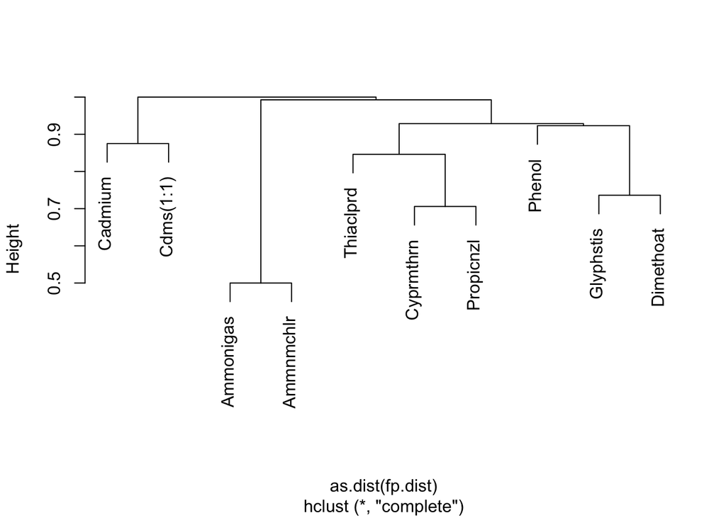

```r
# plot
plot(cls, main = "", labels = labels)
```

Not surprisingly, ammonia and ammonium chloride have the highest similarity. In the package [vignette](https://cran.r-project.org/web/packages/rcdk/vignettes/using-rcdk.html) it is also described how you could identify the most similar target molecule, for example, if you wanted to use this in prediction. In addition, the vignette further shows what you can do with the `rcdk` package.

If you are interested, also check out the package `ChemmineR`, which provides multiple functions for chemical informatics. Consider going through the [online tutorial](https://www.bioconductor.org/packages/devel/bioc/vignettes/ChemmineR/inst/doc/ChemmineR.html#Searching_PubChem).

Finally, we retrieve biological and ecological complementary information that may be useful for prediction. As for the chemicals, we first extract the unique taxa we have.

```r
ourtaxa <- dat5 %>%
                    select(tax_family, tax_genus, tax_taxon) %>%
                    distinct()
# count chemicals
nrow(ourtaxa)
```

```
## [1] 44
```

```r
ourtaxa
```

| tax_family | tax_genus | tax_taxon |
| --- | --- | --- |
| Baetidae | Baetis | Baetis harrisoni |
| Baetidae | Baetis | Baetis rhodani |
| Baetidae | Baetis | Baetis tricaudatus |
| Baetidae | Callibaetis | Callibaetis skokianus |
| Baetidae | Cloeon | Cloeon dipterum |
| Baetidae | Diphetor | Diphetor hageni |
| Baetidae | Fallceon | Fallceon quilleri |
| Baetidae | Neocloeon | Neocloeon triangulifer |
| Caenidae | Caenis | Caenis horaria |
| Caenidae | Caenis | Caenis maxima |

[output cut: 34 more lines]

We have a range of taxa from Ephemeroptera. For several analyses, it can be relevant to have the full taxonomic tree and check whether the names are spelt correctly. This can be done with the package `taxize`. We first resolve the names.

```r
temp_names <- gna_verifier(ourtaxa$tax_taxon)
temp_names
```

| submittedName | dataSourceId | dataSourceTitleShort | curation | recordId | entryDate | sortScore | matchedNameID | matchedName | matchedCardinality | matchedCanonicalSimple | matchedCanonicalFull | currentRecordId | currentNameId | currentName | currentCardinality | currentCanonicalSimple | currentCanonicalFull | taxonomicStatus | isSynonym | editDistance | stemEditDistance | matchType | cardinalityScore | infraSpecificRankScore | fuzzyLessScore | curatedDataScore | authorMatchScore | acceptedNameScore | parsingQualityScore |
| --- | --- | --- | --- | --- | --- | --- | --- | --- | --- | --- | --- | --- | --- | --- | --- | --- | --- | --- | --- | --- | --- | --- | --- | --- | --- | --- | --- | --- | --- |
| Baetis harrisoni | 1 | Catalogue of Life | Curated | 5WBQN | 2026-02-13 | 9.412152 | fb535e55-d249-543a-b0d1-df63efab31a8 | Baetis harrisoni Barnard, 1932 | 2 | Baetis harrisoni | Baetis harrisoni | 5WBQN | fb535e55-d249-543a-b0d1-df63efab31a8 | Baetis harrisoni Barnard, 1932 | 2 | Baetis harrisoni | Baetis harrisoni | Accepted | FALSE | 0 | 0 | Exact | 1 | 0 | 1 | 1.0000000 | 0.1428571 | 1 | 1 |
| Baetis rhodani | 1 | Catalogue of Life | Curated | KD2J | 2026-02-13 | 9.412152 | 490dc13f-5ce0-5917-8cee-cef092951d68 | Baetis rhodani (Pictet, 1843) | 2 | Baetis rhodani | Baetis rhodani | KD2J | 490dc13f-5ce0-5917-8cee-cef092951d68 | Baetis rhodani (Pictet, 1843) | 2 | Baetis rhodani | Baetis rhodani | Accepted | FALSE | 0 | 0 | Exact | 1 | 0 | 1 | 1.0000000 | 0.1428571 | 1 | 1 |
| Baetis tricaudatus | 1 | Catalogue of Life | Curated | KD3F | 2026-02-13 | 9.412152 | 2722f803-ba46-52ad-94e6-fa8c85921393 | Baetis tricaudatus Dodds, 1923 | 2 | Baetis tricaudatus | Baetis tricaudatus | KD3F | 2722f803-ba46-52ad-94e6-fa8c85921393 | Baetis tricaudatus Dodds, 1923 | 2 | Baetis tricaudatus | Baetis tricaudatus | Accepted | FALSE | 0 | 0 | Exact | 1 | 0 | 1 | 1.0000000 | 0.1428571 | 1 | 1 |
| Callibaetis skokianus | 12 | EOL | AutoCurated | bare-name-50934668 | 2025-02-04 | 9.410386 | 8625e148-6ae0-54a5-a625-d20807f64270 | Callibaetis skokianus | 2 | Callibaetis skokianus | Callibaetis skokianus |  |  |  | 0 |  |  | N/A | FALSE | 0 | 0 | Exact | 1 | 0 | 1 | 0.3333333 | 0.1428571 | 0 | 1 |
| Cloeon dipterum | 1 | Catalogue of Life | Curated | 5ZC6V | 2026-02-13 | 9.412152 | ca360764-b063-525e-845e-af4abae6e8a0 | Cloeon dipterum (Linnaeus, 1761) | 2 | Cloeon dipterum | Cloeon dipterum | 5ZC6V | ca360764-b063-525e-845e-af4abae6e8a0 | Cloeon dipterum (Linnaeus, 1761) | 2 | Cloeon dipterum | Cloeon dipterum | Accepted | FALSE | 0 | 0 | Exact | 1 | 0 | 1 | 1.0000000 | 0.1428571 | 1 | 1 |
| Diphetor hageni | 1 | Catalogue of Life | Curated | 36FPK | 2026-02-13 | 9.412152 | 77c6753f-a5d9-5ee3-aefc-72d5d8f96b9a | Diphetor hageni (Eaton, 1884) | 2 | Diphetor hageni | Diphetor hageni | 36FPK | 77c6753f-a5d9-5ee3-aefc-72d5d8f96b9a | Diphetor hageni (Eaton, 1884) | 2 | Diphetor hageni | Diphetor hageni | Accepted | FALSE | 0 | 0 | Exact | 1 | 0 | 1 | 1.0000000 | 0.1428571 | 1 | 1 |
| Fallceon quilleri | 1 | Catalogue of Life | Curated | 3DTQN | 2026-02-13 | 9.412152 | 955a7d13-1586-5b7d-ac09-0c9a6eaf77f7 | Fallceon quilleri (Dodds, 1923) | 2 | Fallceon quilleri | Fallceon quilleri | 3DTQN | 955a7d13-1586-5b7d-ac09-0c9a6eaf77f7 | Fallceon quilleri (Dodds, 1923) | 2 | Fallceon quilleri | Fallceon quilleri | Accepted | FALSE | 0 | 0 | Exact | 1 | 0 | 1 | 1.0000000 | 0.1428571 | 1 | 1 |
| Neocloeon triangulifer | 12 | EOL | AutoCurated | bare-name-55590525 | 2025-02-04 | 9.410386 | ad4e840a-c668-5ffd-8728-8ebf93210744 | Neocloeon triangulifer | 2 | Neocloeon triangulifer | Neocloeon triangulifer |  |  |  | 0 |  |  | N/A | FALSE | 0 | 0 | Exact | 1 | 0 | 1 | 0.3333333 | 0.1428571 | 0 | 1 |
| Caenis horaria | 1 | Catalogue of Life | Curated | P9LD | 2026-02-13 | 9.412152 | de9f0397-8e15-54ba-80e0-1a94a2fd5c4e | Caenis horaria (Linnaeus, 1758) | 2 | Caenis horaria | Caenis horaria | P9LD | de9f0397-8e15-54ba-80e0-1a94a2fd5c4e | Caenis horaria (Linnaeus, 1758) | 2 | Caenis horaria | Caenis horaria | Accepted | FALSE | 0 | 0 | Exact | 1 | 0 | 1 | 1.0000000 | 0.1428571 | 1 | 1 |
| Caenis maxima | 12 | EOL | AutoCurated | bare-name-68379457 | 2025-02-04 | 9.410386 | 2e20c02a-13a1-5698-9217-20dfc048cb1b | Caenis maxima | 2 | Caenis maxima | Caenis maxima |  |  |  | 0 |  |  | N/A | FALSE | 0 | 0 | Exact | 1 | 0 | 1 | 0.3333333 | 0.1428571 | 0 | 1 |

[output cut: 34 more lines]

We obtain a whole bunch of information including a cardinality score, which tells us something about the degree of uniqueness or ambiguity of our query name in the database. The score ranges from 1 to 0, where 1 means that the name uniquely and confidently matches one taxon. The variable *acceptedNameScore* is a bit simpler and tells us whether the name is accepted (valid) in the database. This is often sufficient. Let us quickly check the matched database names and scores.

```r
temp_names %>% select(submittedName, matchedName, acceptedNameScore)
```

| submittedName | matchedName | acceptedNameScore |
| --- | --- | --- |
| Baetis harrisoni | Baetis harrisoni Barnard, 1932 | 1 |
| Baetis rhodani | Baetis rhodani (Pictet, 1843) | 1 |
| Baetis tricaudatus | Baetis tricaudatus Dodds, 1923 | 1 |
| Callibaetis skokianus | Callibaetis skokianus | 0 |
| Cloeon dipterum | Cloeon dipterum (Linnaeus, 1761) | 1 |
| Diphetor hageni | Diphetor hageni (Eaton, 1884) | 1 |
| Fallceon quilleri | Fallceon quilleri (Dodds, 1923) | 1 |
| Neocloeon triangulifer | Neocloeon triangulifer | 0 |
| Caenis horaria | Caenis horaria (Linnaeus, 1758) | 1 |
| Caenis maxima | Caenis maxima | 0 |

[output cut: 34 more lines]

All fine, we do not have to deal with spelling errors or alike. We can also use the `taxize` package to add taxonomic information. This is done with the function `classification()`. This takes a bit, therefore we limit this to the first 10 taxa.

[output not shown]

```
## ══  10 queries  ══════════════
```

```
##
## Retrieving data for taxon 'Baetis harrisoni'
```

```
## ✔  Found:  Baetis+harrisoni
```

```
##
## Retrieving data for taxon 'Baetis rhodani'
```

```
## ✔  Found:  Baetis+rhodani
```

```
##
## Retrieving data for taxon 'Baetis tricaudatus'
```

```
## ✔  Found:  Baetis+tricaudatus
```

```
##
## Retrieving data for taxon 'Callibaetis skokianus'
```

```
## Not found. Consider checking the spelling or alternate classification
```

```
##
## Retrieving data for taxon 'Cloeon dipterum'
```

```
## ✔  Found:  Cloeon+dipterum
```

```
##
## Retrieving data for taxon 'Diphetor hageni'
```

```
## ✔  Found:  Diphetor+hageni
```

```
##
## Retrieving data for taxon 'Fallceon quilleri'
```

```
## ✔  Found:  Fallceon+quilleri
```

```
##
## Retrieving data for taxon 'Neocloeon triangulifer'
```

```
## ✔  Found:  Neocloeon+triangulifer
```

```
##
## Retrieving data for taxon 'Caenis horaria'
```

```
## ✔  Found:  Caenis+horaria
```

```
##
## Retrieving data for taxon 'Caenis maxima'
```

```
## Not found. Consider checking the spelling or alternate classification
```

[output not shown]

[output not shown]

```
## ══  10 queries  ══════════════
```

```
##
## Retrieving data for taxon 'Baetis harrisoni'
```

```
## ✔  Found:  Baetis harrisoni
```

```
##
## Retrieving data for taxon 'Baetis rhodani'
```

```
## ✔  Found:  Baetis rhodani
```

```
##
## Retrieving data for taxon 'Baetis tricaudatus'
```

```
##
## More than one GBIF ID found for taxon 'Baetis tricaudatus'!
##
##             Enter rownumber of taxon (other inputs will return 'NA'):
```

```
##     gbifid                 scientificname    rank   status matchtype
## 1  1407927 Baetis tricaudatus Dodds, 1923 species ACCEPTED     EXACT
## 2 10301858        Baetis tricaudatus A BG species DOUBTFUL     EXACT
## 3 10453310        Baetis tricaudatus C BG species DOUBTFUL     EXACT
## 4 10569034        Baetis tricaudatus D BG species DOUBTFUL     EXACT
## 5  9884932        Baetis tricaudatus B BG species DOUBTFUL     EXACT
## 6  1407922  Baetis bicaudatus Dodds, 1923 species ACCEPTED     FUZZY
```

```
##
## Returned 'NA'!
```

```
## ✖  Not Found:  Baetis tricaudatus
```

```
##
## Retrieving data for taxon 'Callibaetis skokianus'
```

```
## ✔  Found:  Callibaetis skokianus
```

```
##
## Retrieving data for taxon 'Cloeon dipterum'
```

```
## ✔  Found:  Cloeon dipterum
```

```
##
## Retrieving data for taxon 'Diphetor hageni'
```

```
## ✔  Found:  Diphetor hageni
```

```
##
## Retrieving data for taxon 'Fallceon quilleri'
```

```
## ✔  Found:  Fallceon quilleri
```

```
##
## Retrieving data for taxon 'Neocloeon triangulifer'
```

```
## ✔  Found:  Neocloeon triangulifer
```

```
##
## Retrieving data for taxon 'Caenis horaria'
```

```
## ✔  Found:  Caenis horaria
```

```
##
## Retrieving data for taxon 'Caenis maxima'
```

```
## ✔  Found:  Caenis maxima
## ══  Results  ═════════════════
##
## • Total: 10
## • Found: 9
## • Not Found: 1
```

```
## $`Baetis harrisoni`
##               name    rank      id
## 1         Animalia kingdom       1
## 2       Arthropoda  phylum      54
## 3          Insecta   class     216
## 4    Ephemeroptera   order    1225
## 5         Baetidae  family    7865
## 6           Baetis   genus 1407108
## 7 Baetis harrisoni species 6932410
##
## $`Baetis rhodani`
##             name    rank      id
## 1       Animalia kingdom       1
## 2     Arthropoda  phylum      54
## 3        Insecta   class     216
## 4  Ephemeroptera   order    1225
## 5       Baetidae  family    7865
## 6         Baetis   genus 1407108
## 7 Baetis rhodani species 4481106
##
## $`Baetis tricaudatus`
## [1] NA
##
## $`Callibaetis skokianus`
##                   name    rank      id
## 1             Animalia kingdom       1
## 2           Arthropoda  phylum      54
## 3              Insecta   class     216
## 4        Ephemeroptera   order    1225
## 5             Baetidae  family    7865
## 6          Callibaetis   genus 1407575
## 7 Callibaetis skokiana species 7196843
##
## $`Cloeon dipterum`
##              name    rank      id
## 1        Animalia kingdom       1
## 2      Arthropoda  phylum      54
## 3         Insecta   class     216
## 4   Ephemeroptera   order    1225
## 5        Baetidae  family    7865
```

[output cut: 42 more lines]

```
##
## $`Caenis maxima`
##                 name    rank      id
## 1           Animalia kingdom       1
## 2         Arthropoda  phylum      54
## 3            Insecta   class     216
## 4      Ephemeroptera   order    1225
## 5     Neoephemeridae  family    4296
## 6        Neoephemera   genus 1409019
## 7 Neoephemera maxima species 4481565
##
## attr(,"class")
## [1] "classification"
## attr(,"db")
## [1] "gbif"
```

We obtain information on the taxonomy from kingdom to species. We can also query specific information, e.g. family level:

[output not shown]

[output not shown]

[output not shown]

[output not shown]

[output not shown]

[output not shown]

[output not shown]

[output not shown]

[output not shown]

[output not shown]

[output not shown]

[output not shown]

[output not shown]

[output not shown]

[output not shown]

[output not shown]

[output not shown]

[output not shown]

[output not shown]

[output not shown]

[output not shown]

[output not shown]

[output not shown]

[output not shown]

[output not shown]

[output not shown]

[output not shown]

[output not shown]

[output not shown]

[output not shown]

[output not shown]

[output not shown]

[output not shown]

[output not shown]

[output not shown]

[output not shown]

[output not shown]

[output not shown]

[output not shown]

[output not shown]

[output not shown]

[output not shown]

[output not shown]

[output not shown]

[output not shown]

[output not shown]

[output not shown]

[output not shown]

[output not shown]

[output not shown]

[output not shown]

[output not shown]

[output not shown]

[output not shown]

[output not shown]

[output not shown]

[output not shown]

[output not shown]

[output not shown]

[output not shown]

[output not shown]

[output not shown]

[output not shown]

[output not shown]

[output not shown]

[output not shown]

[output not shown]

[output not shown]

[output not shown]

[output not shown]

[output not shown]

[output not shown]

[output not shown]

[output not shown]

[output not shown]

[output not shown]

[output not shown]

[output not shown]

[output not shown]

[output not shown]

[output not shown]

[output not shown]

[output not shown]

[output not shown]

```
## ══  2 queries  ═══════════════
```

```
##
## Retrieving data for taxon 'Heptageniidae'
```

```
## ✔  Found:  Heptageniidae
```

```
##
## Retrieving data for taxon 'Ephemeridae'
```

```
## ✔  Found:  Ephemeridae
## ══  Results  ═════════════════
##
## • Total: 2
## • Found: 2
## • Not Found: 0
```

|  | name | rank | key | name_type |
| --- | --- | --- | --- | --- |
| 1 | Afronurus abracadabrus | species | 6933572 | canonicalname |
| 2 | Afronurus aethereus | species | 6933531 | canonicalname |
| 3 | Afronurus alces | species | 7645093 | canonicalname |
| 4 | Afronurus assamensis | species | 6933533 | canonicalname |
| 5 | Afronurus barnardi | species | 6933579 | canonicalname |
| 6 | Afronurus bruneiensis | species | 7197315 | canonicalname |

|  | name | rank | key | name_type |
| --- | --- | --- | --- | --- |
| 1 | Afromera aequatorialis | species | 6934442 | canonicalname |
| 2 | Afromera congolana | species | 6934441 | canonicalname |
| 3 | Afromera evae | species | 6934440 | canonicalname |
| 4 | Afromera gilliesi | species | 6934438 | canonicalname |
| 5 | Afromera natalensis | species | 6934436 | canonicalname |
| 6 | Afromera troubati | species | 6934439 | canonicalname |

This yields to 250 taxa, though the list may still have some gaps.

Trait information on taxa is available in multiple databases, but direct access through R is patchy and not straightforward. Examples include the packages:

- [traits](https://docs.ropensci.org/traits/), which covers a range of organism groups
- [TR8](https://cran.r-project.org/web/packages/TR8/index.html), which covers different databases for plants
- [rtry](https://cran.r-project.org/web/packages/rtry/index.html), which simplifies working with the TRY plant trait database
- biomonitoR, which provides some traits for freshwater organisms.

Theoretically, the `biomonitoR` package could be used to add traits of freshwater organisms to our data, but it relies on an internal reference database for taxa, which makes its use a bit cumbersome if our taxa are not included. However, let’s use it to add some trait information. We can use the function `assign_traits()` to assign trait information from the [Tachet database](https://doi.org/10.1023/A:1017042921298).

```r
ourtaxa_up <- ourtaxa %>%
              mutate(Taxa = tax_taxon,
                     Site = 10)
# function requires a column called Taxa and abundances in a site
# as a workaround, we add a dummy column with abundances
data_bio <- as_biomonitor(ourtaxa_up[ , 4:5])
```

```
## Some taxa were excluded, check with traceB = TRUE
```

```r
data_bio
```

```
##       Phylum   Class Subclass         Order          Family       Subfamily
## 1 Arthropoda Insecta          Ephemeroptera        Baetidae
## 2 Arthropoda Insecta          Ephemeroptera        Caenidae
## 3 Arthropoda Insecta          Ephemeroptera        Caenidae
## 4 Arthropoda Insecta          Ephemeroptera        Baetidae
## 5 Arthropoda Insecta          Ephemeroptera Polymitarcyidae Polymitarcyinae
## 6 Arthropoda Insecta          Ephemeroptera   Heptageniidae
## 7 Arthropoda Insecta          Ephemeroptera Leptophlebiidae
## 8 Arthropoda Insecta          Ephemeroptera Leptophlebiidae
##   Tribus            Genus                       Species Subspecies
## 1                  Baetis                Baetis rhodani
## 2                  Caenis                Caenis horaria
## 3                  Caenis                Caenis robusta
## 4                  Cloeon               Cloeon dipterum
## 5                 Ephoron                 Ephoron virgo
## 6              Heptagenia          Heptagenia sulphurea
## 7            Leptophlebia        Leptophlebia marginata
## 8        Paraleptophlebia Paraleptophlebia submarginata
##                            Taxa Site
## 1                Baetis rhodani   10
## 2                Caenis horaria   10
## 3                Caenis robusta   10
## 4               Cloeon dipterum   10
## 5                 Ephoron virgo   10
## 6          Heptagenia sulphurea   10
## 7        Leptophlebia marginata   10
## 8 Paraleptophlebia submarginata   10
```

```r
# most taxa not found (as given under suggested taxon names)

# but we can use an own tree to improve the matching
dfref_gbif <- get_gbif_taxa_tree(ourtaxa_up$Taxa)
```

```
## [1] "---- 1 of 44 ---- Baetis harrisoni ----"
## [1] "---- 2 of 44 ---- Baetis rhodani ----"
## [1] "---- 3 of 44 ---- Baetis tricaudatus ----"
## [1] "---- 4 of 44 ---- Callibaetis skokianus ----"
## [1] "---- 5 of 44 ---- Cloeon dipterum ----"
## [1] "---- 6 of 44 ---- Diphetor hageni ----"
## [1] "---- 7 of 44 ---- Fallceon quilleri ----"
## [1] "---- 8 of 44 ---- Neocloeon triangulifer ----"
## [1] "---- 9 of 44 ---- Caenis horaria ----"
## [1] "---- 10 of 44 ---- Caenis maxima ----"
## [1] "---- 11 of 44 ---- Caenis miliaria ----"
## [1] "---- 12 of 44 ---- Caenis moesta ----"
## [1] "---- 13 of 44 ---- Caenis robusta ----"
## [1] "---- 14 of 44 ---- Coloburiscus humeralis ----"
## [1] "---- 15 of 44 ---- Drunella grandis ----"
```

[output cut: 29 more lines]

```r
# a few taxa are synonyms of accepted names
dfref_gbif$status
```

| taxa | status |
| --- | --- |
| Baetis harrisoni | ACCEPTED |
| Baetis rhodani | ACCEPTED |
| Baetis tricaudatus | ACCEPTED |
| Callibaetis skokianus | ACCEPTED |
| Cloeon dipterum | ACCEPTED |
| Diphetor hageni | ACCEPTED |
| Fallceon quilleri | ACCEPTED |
| Neocloeon triangulifer | DOUBTFUL |
| Caenis horaria | ACCEPTED |
| Caenis maxima | SYNONYM |

[output cut: 34 more lines]

```r
dfref_gbif_comb <- cbind(dfref_gbif$taxonomy, dfref_gbif$status)
# Taxa is the name in our data, Species the GBIF name

# now we can convert to a biomonitor object
data_asb <- as_biomonitor(ourtaxa_up[ , 4:5], dfref = dfref_gbif$taxonomy, group = "mi", correct_names = FALSE)
```

```
## Some taxa were excluded, check with traceB = TRUE
```

```r
data_asb
```

```
##        Phylum   Class Subclass         Order          Family Subfamily Tribus
## 1  Arthropoda Insecta          Ephemeroptera Leptophlebiidae
## 2  Arthropoda Insecta          Ephemeroptera Leptophlebiidae
## 3  Arthropoda Insecta          Ephemeroptera        Baetidae
## 4  Arthropoda Insecta          Ephemeroptera        Baetidae
## 5  Arthropoda Insecta          Ephemeroptera        Baetidae
## 6  Arthropoda Insecta          Ephemeroptera        Caenidae
## 7  Arthropoda Insecta          Ephemeroptera  Neoephemeridae
## 8  Arthropoda Insecta          Ephemeroptera        Caenidae
## 9  Arthropoda Insecta          Ephemeroptera        Caenidae
## 10 Arthropoda Insecta          Ephemeroptera        Caenidae
## 11 Arthropoda Insecta          Ephemeroptera        Baetidae
## 12 Arthropoda Insecta          Ephemeroptera  Coloburiscidae
## 13 Arthropoda Insecta          Ephemeroptera        Baetidae
## 14 Arthropoda Insecta          Ephemeroptera  Ephemerellidae
```

[output cut: 117 more lines]

```r
# one taxon was removed because it had no match, try to fix this, what could you do?

# we need to run the function aggregate_taxa before, otherwise trait assignment does not work.
# This function harmonizes taxonomic levels
data_asb_agg <- aggregate_taxa(data_asb)
data_asb_agg
```

```
## $Phylum
##       Phylum Site
## 1 Arthropoda  430
##
## $Class
##     Class Site
## 1 Insecta  430
##
## $Subclass
##     Subclass Site
## 1 unassigned  430
##
## $Order
##           Order Site
## 1 Ephemeroptera  430
```

[output cut: 282 more lines]

```r
# Now we assign traits
data_ts <- assign_traits(data_asb_agg, tax_lev = "Family")
data_ts
```

| Taxa | Taxa_db | Traits_taxlev | Traits_real | Taxonomic_distance | LONGITUDINAL_1 | LONGITUDINAL_2 | LONGITUDINAL_3 | LONGITUDINAL_4 | LONGITUDINAL_5 | LONGITUDINAL_6 | LONGITUDINAL_7 | LONGITUDINAL_8 | TRANSVERSAL_1 | TRANSVERSAL_2 | TRANSVERSAL_3 | TRANSVERSAL_4 | TRANSVERSAL_5 | TRANSVERSAL_6 | TRANSVERSAL_7 | ALTITUDE_1 | ALTITUDE_2 | ALTITUDE_3 | SUBSTRATE_1 | SUBSTRATE_2 | SUBSTRATE_3 | SUBSTRATE_4 | SUBSTRATE_5 | SUBSTRATE_6 | SUBSTRATE_7 | … |
| --- | --- | --- | --- | --- | --- | --- | --- | --- | --- | --- | --- | --- | --- | --- | --- | --- | --- | --- | --- | --- | --- | --- | --- | --- | --- | --- | --- | --- | --- | --- |
| Leptophlebiidae | Family | Choroterpes picteti | Species | 4 | 0.00000000 | 0.00000000 | 0.20000000 | 0.3000000 | 0.30000000 | 0.10000000 | 0.00000000 | 0.10000000 | 0.0000000 | 0.7500000 | 0.0000000 | 0.00000000 | 0.00000000 | 0.2500000 | 0 | 1.0000000 | 0.0000000 | 0.0000000 | 0.18181818 | 0.00000000 | 0.18181818 | 0.18181818 | 0.18181818 | 0 | 0.18181818 | … |
| Leptophlebiidae | Family | Habroleptoides | Genus | 3 | 0.08333333 | 0.25000000 | 0.41666667 | 0.1666667 | 0.08333333 | 0.00000000 | 0.00000000 | 0.00000000 | 0.0000000 | 1.0000000 | 0.0000000 | 0.00000000 | 0.00000000 | 0.0000000 | 0 | 0.4000000 | 0.4000000 | 0.2000000 | 0.30000000 | 0.20000000 | 0.10000000 | 0.00000000 | 0.00000000 | 0 | 0.20000000 | … |
| Leptophlebiidae | Family | Habrophlebia | Genus | 3 | 0.00000000 | 0.16666667 | 0.25000000 | 0.3333333 | 0.08333333 | 0.08333333 | 0.00000000 | 0.08333333 | 0.1666667 | 0.5000000 | 0.1666667 | 0.00000000 | 0.00000000 | 0.1666667 | 0 | 0.7500000 | 0.2500000 | 0.0000000 | 0.00000000 | 0.00000000 | 0.10000000 | 0.10000000 | 0.20000000 | 0 | 0.20000000 | … |
| Leptophlebiidae | Family | Leptophlebia | Genus | 3 | 0.00000000 | 0.00000000 | 0.22222222 | 0.3333333 | 0.22222222 | 0.00000000 | 0.00000000 | 0.22222222 | 0.1000000 | 0.3000000 | 0.1000000 | 0.10000000 | 0.30000000 | 0.1000000 | 0 | 0.7500000 | 0.2500000 | 0.0000000 | 0.16666667 | 0.08333333 | 0.08333333 | 0.00000000 | 0.25000000 | 0 | 0.16666667 | … |
| Leptophlebiidae | Family | Paraleptophlebia | Genus | 3 | 0.10000000 | 0.20000000 | 0.30000000 | 0.2000000 | 0.10000000 | 0.00000000 | 0.00000000 | 0.10000000 | 0.4285714 | 0.4285714 | 0.0000000 | 0.00000000 | 0.00000000 | 0.1428571 | 0 | 0.5000000 | 0.3333333 | 0.1666667 | 0.18181818 | 0.18181818 | 0.09090909 | 0.00000000 | 0.18181818 | 0 | 0.18181818 | … |
| Leptophlebiidae | Family | Thraulus bellus | Species | 4 | 0.00000000 | 0.00000000 | 0.00000000 | 0.1428571 | 0.14285714 | 0.14285714 | 0.00000000 | 0.57142857 | 0.0000000 | 0.2500000 | 0.7500000 | 0.00000000 | 0.00000000 | 0.0000000 | 0 | 0.6000000 | 0.4000000 | 0.0000000 | 0.50000000 | 0.00000000 | 0.00000000 | 0.00000000 | 0.33333333 | 0 | 0.00000000 | … |
| Baetidae | Family | Acentrella sinaica | Species | 4 | 0.00000000 | 0.28571429 | 0.42857143 | 0.2857143 | 0.00000000 | 0.00000000 | 0.00000000 | 0.00000000 | 1.0000000 | 0.0000000 | 0.0000000 | 0.00000000 | 0.00000000 | 0.0000000 | 0 | 0.7500000 | 0.2500000 | 0.0000000 | 1.00000000 | 0.00000000 | 0.00000000 | 0.00000000 | 0.00000000 | 0 | 0.00000000 | … |
| Baetidae | Family | Baetis | Genus | 3 | 0.14285714 | 0.19047619 | 0.19047619 | 0.1904762 | 0.14285714 | 0.09523810 | 0.00000000 | 0.04761905 | 0.4444444 | 0.3333333 | 0.0000000 | 0.00000000 | 0.11111111 | 0.1111111 | 0 | 0.5000000 | 0.3333333 | 0.1666667 | 0.25000000 | 0.12500000 | 0.06250000 | 0.00000000 | 0.31250000 | 0 | 0.18750000 | … |
| Baetidae | Family | Baetopus tenellus | Species | 4 | 0.00000000 | 0.00000000 | 0.14285714 | 0.4285714 | 0.42857143 | 0.00000000 | 0.00000000 | 0.00000000 | 0.5000000 | 0.5000000 | 0.0000000 | 0.00000000 | 0.00000000 | 0.0000000 | 0 | 1.0000000 | 0.0000000 | 0.0000000 | 0.50000000 | 0.33333333 | 0.00000000 | 0.00000000 | 0.16666667 | 0 | 0.00000000 | … |
| Baetidae | Family | Centroptilum luteolum | Species | 4 | 0.07692308 | 0.15384615 | 0.15384615 | 0.3076923 | 0.15384615 | 0.00000000 | 0.00000000 | 0.15384615 | 0.0000000 | 0.5000000 | 0.1666667 | 0.00000000 | 0.00000000 | 0.3333333 | 0 | 0.7500000 | 0.2500000 | 0.0000000 | 0.08333333 | 0.16666667 | 0.08333333 | 0.00000000 | 0.41666667 | 0 | 0.08333333 | … |

[output cut: 16 more lines]

**Try setting `correct_names = TRUE` in the `as_biomonitor()` function.**

Now we have some traits at the family level for several of our species. However, the function would not run at genus level because of too few matches. It would need more fiddling around to have more matches. Generally, it may be easier and more flexible to import the trait database into R and link the data manually. For example, for freshwater organisms, a more current database is the freshwaterecology.info database, which can be [accessed via API](https://www.freshwaterecology.info/fweapi2docu.php#docur). For further details on using the biomonitoR package, in particular for calculating ecological metrics, have a look at the vignette.

```r
vignette("functional", package = "biomonitoR")
```

Moreover, a recent paper on this package by [Laini et al. 2022](https://peerj.com/articles/14183/) provides commented R code in the Supplemental information that may be helpful.

Finally, to access physiological information for species, we could query the [Add my pet database](https://www.bio.vu.nl/thb/deb/deblab/add_my_pet/). There, we can download the .zip file *AmPdata*, which contains data in the Matlab format. With the package `R.matlab` we can read these files.

```r
# NOT run
# you would need to download the data into your working directory path, but the data set is relatively big and takes several minutes to import.

# Load the mat files
allStat <- readMat("AmPdata/allStat.mat")
popStat <- readMat("AmPdata/popStat.mat")
allUnits <- readMat("AmPdata/allUnits.mat")
allLabel <- readMat("AmPdata/allLabel.mat")
```

```r
# But we can load an R object where I saved the information
# Will not run on your machine if you do not have the file from github in your working directory
load('allStat_addmypet.RData')
```

The loaded objects are complex, often nested lists. For example:

```r
str(allStat[[1]][1])
```

```
## List of 1
##  $ :List of 245
##   ..$ : chr [1, 1] "Haliclona_oculata"
##   ..$ : chr [1, 1] "Mermaid's glove"
##   ..$ : chr [1, 1] "Chalinidae"
##   ..$ : chr [1, 1] "Haplosclerida"
##   ..$ : chr [1, 1] "Demospongiae"
##   ..$ : chr [1, 1] "Porifera"
##   ..$ : chr [1, 1] "3JCBW"
##   ..$ :List of 8
##   .. ..$ :List of 1
##   .. .. ..$ :List of 1
##   .. .. .. ..$ : chr [1, 1] "MC"
##   .. .. ..- attr(*, "dim")= int [1:2] 1 1
##   .. ..$ :List of 2
##   .. .. ..$ :List of 1
##   .. .. .. ..$ : chr [1, 1] "MAN"
##   .. .. ..$ :List of 1
##   .. .. .. ..$ : chr [1, 1] "MAS"
##   .. .. ..- attr(*, "dim")= int [1:2] 1 2
##   .. ..$ :List of 2
##   .. .. ..$ :List of 1
##   .. .. .. ..$ : chr [1, 1] "0bMp"
##   .. .. ..$ :List of 1
##   .. .. .. ..$ : chr [1, 1] "biMb"
##   .. .. ..- attr(*, "dim")= int [1:2] 1 2
##   .. ..$ :List of 1
##   .. .. ..$ :List of 1
##   .. .. .. ..$ : chr [1, 1] "Mp"
##   .. .. ..- attr(*, "dim")= int [1:2] 1 1
##   .. ..$ : list()
##   .. ..$ :List of 1
##   .. .. ..$ :List of 1
##   .. .. .. ..$ : chr [1, 1] "biP"
##   .. .. ..- attr(*, "dim")= int [1:2] 1 1
##   .. ..$ :List of 1
##   .. .. ..$ :List of 1
##   .. .. .. ..$ : chr [1, 1] "Hh"
##   .. .. ..- attr(*, "dim")= int [1:2] 1 1
##   .. ..$ :List of 1
```

[output cut: 144 more lines]

```
##   ..$ : num [1, 1] 0.0139
##   ..$ : num [1, 1] 0.144
##   ..$ : num [1, 1] 1345
##   ..$ : num [1, 1] 0.995
##   ..$ : num [1, 1] 1.16
##   ..$ : num [1, 1] 3.73
##   ..$ : num [1, 1] 0
##   ..$ : num [1, 1] 0
##   ..$ : num [1, 1] 0.995
##   .. [list output truncated]
##   ..- attr(*, "dim")= int [1:3] 245 1 1
##   ..- attr(*, "dimnames")=List of 3
##   .. ..$ : chr [1:245] "species" "species.en" "family" "order" ...
##   .. ..$ : NULL
##   .. ..$ : NULL
```

Each of the list corresponds to a species. For example, if we searched for data on Daphnia magna, we could extract this as follows.

```r
# we need to set up a function that searches the lists
get_amp_species <- function(species_name, data_file) {
  for (entry in data_file[[1]]) {
    if (!is.null(entry[[1]]) && entry[[1]][1] == species_name) {
      return(entry)
    }
  }
  return(NULL)
}


speciesName <- "Daphnia_magna"
# note that the names are saved with an underscore
speciesData <- get_amp_species(speciesName, allStat)
speciesData
```

```
## , , 1
##
##            [,1]
## species    "Daphnia_magna"
## species.en "Waterflea"
## family     "Daphniidae"
## order      "Anomopoda"
## class      "Branchiopoda"
## phylum     "Arthropoda"
## id.CoL     "6CCSV"
## ecoCode    list,8
## model      "std"
## MRE        0.193555
## SMSE       0.1352669
## COMPLETE   6
## data       list,19
## author     list,2
## date.subm  numeric,3
## date.acc   numeric,3
## T.ref      293.15
## T.typical  293.15
## z          0.1516
## F.m        30.17
## kap.X      0.9
## kap.P      0.05
## v          0.1858
## kap        0.5809
## kap.R      0.95
## p.M        1200
## p.T        0
## k.J        0.2537
## E.G        4400
## E.Hb       0.05464
## E.Hp       1.09
## h.a        0.0002794
## s.G        -0.3
## T.A        6400
## d.X        0.17
## d.V        0.19
## d.E        0.19
```

[output cut: 191 more lines]

```
## SDA.b      0.09376598
## VO.b       -0.0421716
## p.Tb       0.1141173
## RQ.p       0.9195402
## UQ.p       0.137931
## WQ.p       0.6206897
## SDA.p      0.09376598
## VO.p       -0.02219446
## p.Tp       1.089068
## RQ.i       0.9195402
## UQ.i       0.137931
## WQ.i       0.6206897
## SDA.i      0.09376598
## VO.i       -0.0100778
## p.Ti       4.99793
```

From there, you could convert it into a data.frame or tibble for analysis.

As a final step, let us have a look, which species, families and orders are included.

```r
species_names <- sapply(allStat[[1]], function(x) x[[1]][1])
head(species_names, 10)
```

```
##  [1] "Haliclona_oculata"   "Actinia_equina"      "Metridium_senile"
##  [4] "Ptilosarcus_gurneyi" "Chironex_fleckeri"   "Hydra_viridissima"
##  [7] "Pelagia_noctiluca"   "Cyanea_capillata"    "Cassiopea_xamachana"
## [10] "Rhizostoma_octopus"
```

```r
# note that this would still contain duplicates

# extract families
family_names <- sapply(allStat[[1]], function(x) x[[3]][1])
# we remove duplicates
famil_nam_dedup <- unique(family_names)
# only 1041 of 6012 left

order_names <- sapply(allStat[[1]], function(x) x[[4]][1])

# extract all families of order Ephemeroptera
families_ephem <- family_names[order_names == "Ephemeroptera"]
families_ephem
```

```
## [1] "Heptageniidae"   "Heptageniidae"   "Heptageniidae"   "Oligoneuriidae"
## [5] "Baetidae"        "Baetidae"        "Leptophlebiidae"
```

Only 4 families are represented in the database, which relate to 7 taxa.

**If you want to practice, choose a different organism group in the beginning, which would also translate into a different set of tested chemicals, and adjust the code for these taxa!**